# Risk Factor Analysis

## Outcome Variable

**Outcome Variable:** pers_wasted624

## Predictor Variables

**Intervention Variable:** ever_sstunted06

**Adjustment Set:**

unadjusted

## Stratifying Variables

The analysis was stratified on these variable(s):

- studyid
- country

## Data Summary

| studyid | country | ever_sstunted06 | pers_wasted624 | n_cell | n |
| --- | --- | --- | --- | --- | --- |
| ki0047075b-MAL-ED | BANGLADESH | 0 | 0 | 208 | 239 |
| ki0047075b-MAL-ED | BANGLADESH | 0 | 1 | 16 | 239 |
| ki0047075b-MAL-ED | BANGLADESH | 1 | 0 | 13 | 239 |
| ki0047075b-MAL-ED | BANGLADESH | 1 | 1 | 2 | 239 |
| ki0047075b-MAL-ED | BRAZIL | 0 | 0 | 186 | 202 |
| ki0047075b-MAL-ED | BRAZIL | 0 | 1 | 2 | 202 |
| ki0047075b-MAL-ED | BRAZIL | 1 | 0 | 14 | 202 |
| ki0047075b-MAL-ED | BRAZIL | 1 | 1 | 0 | 202 |
| ki0047075b-MAL-ED | INDIA | 0 | 0 | 193 | 234 |
| ki0047075b-MAL-ED | INDIA | 0 | 1 | 22 | 234 |
| ki0047075b-MAL-ED | INDIA | 1 | 0 | 13 | 234 |
| ki0047075b-MAL-ED | INDIA | 1 | 1 | 6 | 234 |
| ki0047075b-MAL-ED | NEPAL | 0 | 0 | 224 | 234 |
| ki0047075b-MAL-ED | NEPAL | 0 | 1 | 2 | 234 |
| ki0047075b-MAL-ED | NEPAL | 1 | 0 | 8 | 234 |
| ki0047075b-MAL-ED | NEPAL | 1 | 1 | 0 | 234 |
| ki0047075b-MAL-ED | PERU | 0 | 0 | 231 | 264 |
| ki0047075b-MAL-ED | PERU | 0 | 1 | 1 | 264 |
| ki0047075b-MAL-ED | PERU | 1 | 0 | 31 | 264 |
| ki0047075b-MAL-ED | PERU | 1 | 1 | 1 | 264 |
| ki0047075b-MAL-ED | SOUTH AFRICA | 0 | 0 | 231 | 258 |
| ki0047075b-MAL-ED | SOUTH AFRICA | 0 | 1 | 2 | 258 |
| ki0047075b-MAL-ED | SOUTH AFRICA | 1 | 0 | 25 | 258 |
| ki0047075b-MAL-ED | SOUTH AFRICA | 1 | 1 | 0 | 258 |
| ki0047075b-MAL-ED | TANZANIA, UNITED REPUBLIC OF | 0 | 0 | 211 | 244 |
| ki0047075b-MAL-ED | TANZANIA, UNITED REPUBLIC OF | 0 | 1 | 0 | 244 |
| ki0047075b-MAL-ED | TANZANIA, UNITED REPUBLIC OF | 1 | 0 | 33 | 244 |
| ki0047075b-MAL-ED | TANZANIA, UNITED REPUBLIC OF | 1 | 1 | 0 | 244 |
| ki1000108-CMC-V-BCS-2002 | INDIA | 0 | 0 | 260 | 368 |
| ki1000108-CMC-V-BCS-2002 | INDIA | 0 | 1 | 17 | 368 |

[output cut: 118 more lines]

The following strata were considered:

- studyid: ki0047075b-MAL-ED, country: BANGLADESH
- studyid: ki0047075b-MAL-ED, country: BRAZIL
- studyid: ki0047075b-MAL-ED, country: INDIA
- studyid: ki0047075b-MAL-ED, country: NEPAL
- studyid: ki0047075b-MAL-ED, country: PERU
- studyid: ki0047075b-MAL-ED, country: SOUTH AFRICA
- studyid: ki0047075b-MAL-ED, country: TANZANIA, UNITED REPUBLIC OF
- studyid: ki1000108-CMC-V-BCS-2002, country: INDIA
- studyid: ki1000108-IRC, country: INDIA
- studyid: ki1000109-EE, country: PAKISTAN
- studyid: ki1000109-ResPak, country: PAKISTAN
- studyid: ki1000304-VITAMIN-A, country: INDIA
- studyid: ki1000304b-SAS-CompFeed, country: INDIA
- studyid: ki1000304b-SAS-FoodSuppl, country: INDIA
- studyid: ki1017093-NIH-Birth, country: BANGLADESH
- studyid: ki1017093b-PROVIDE, country: BANGLADESH
- studyid: ki1017093c-NIH-Crypto, country: BANGLADESH
- studyid: ki1066203-TanzaniaChild2, country: TANZANIA, UNITED REPUBLIC OF
- studyid: ki1101329-Keneba, country: GAMBIA
- studyid: ki1112895-Burkina Faso Zn, country: BURKINA FASO
- studyid: ki1112895-Guatemala BSC, country: GUATEMALA
- studyid: ki1113344-GMS-Nepal, country: NEPAL
- studyid: ki1114097-CMIN, country: BANGLADESH
- studyid: ki1114097-CMIN, country: BRAZIL
- studyid: ki1114097-CMIN, country: GUINEA-BISSAU
- studyid: ki1114097-CMIN, country: PERU
- studyid: ki1114097-CONTENT, country: PERU
- studyid: ki1119695-PROBIT, country: BELARUS
- studyid: ki1126311-ZVITAMBO, country: ZIMBABWE
- studyid: ki1135781-COHORTS, country: GUATEMALA
- studyid: ki1135781-COHORTS, country: INDIA
- studyid: ki1135781-COHORTS, country: PHILIPPINES
- studyid: ki1148112-iLiNS-DOSE, country: MALAWI
- studyid: ki1148112-iLiNS-DYAD-M, country: MALAWI
- studyid: ki1148112-LCNI-5, country: MALAWI
- studyid: kiGH5241-JiVitA-3, country: BANGLADESH
- studyid: kiGH5241-JiVitA-4, country: BANGLADESH

### Dropped Strata

Some strata were dropped due to rare outcomes:

- studyid: ki0047075b-MAL-ED, country: BANGLADESH
- studyid: ki0047075b-MAL-ED, country: BRAZIL
- studyid: ki0047075b-MAL-ED, country: NEPAL
- studyid: ki0047075b-MAL-ED, country: PERU
- studyid: ki0047075b-MAL-ED, country: SOUTH AFRICA
- studyid: ki0047075b-MAL-ED, country: TANZANIA, UNITED REPUBLIC OF
- studyid: ki1017093b-PROVIDE, country: BANGLADESH
- studyid: ki1112895-Burkina Faso Zn, country: BURKINA FASO
- studyid: ki1112895-Guatemala BSC, country: GUATEMALA
- studyid: ki1114097-CMIN, country: BRAZIL
- studyid: ki1114097-CMIN, country: GUINEA-BISSAU
- studyid: ki1114097-CMIN, country: PERU
- studyid: ki1114097-CONTENT, country: PERU
- studyid: ki1119695-PROBIT, country: BELARUS
- studyid: ki1148112-iLiNS-DYAD-M, country: MALAWI
- studyid: ki1148112-LCNI-5, country: MALAWI

## Methods Detail

We’re interested in the causal parameters $E[Y_a]$ for all values of $a \in \mathcal{A}$. These parameters represent the mean outcome if, possibly contrary to fact, we intervened to set all units to have $A=a$. Under the randomization and positivity assumptions, these are identified by the statistical parameters $\psi_a=E_W[E_{Y|A,W}(Y|A=a,W)]$. In addition, we’re interested in the mean of $Y$, $E[Y]$ under no intervention (the observed mean). We will estimate these parameters by using SuperLearner to fit the relevant likelihood factors – $E_{Y|A,W}(Y|A=a,W)$ and $p(A=a|W)$, and then updating our likelihood fit using a joint TMLE.

For unadjusted analyses ($W=\{\}$), initial likelihoods were estimated using Lrnr_glm to estimate the simple $E(Y|A)$ and Lrnr_mean to estimate $p(A)$. For adjusted analyses, a small library containing Lrnr_glmnet, Lrnr_xgboost, and Lrnr_mean was used.

Having estimated these parameters, we will then use the delta method to estimate relative risks and attributable risks relative to a prespecified baseline level of $A$.

# Results Detail

## Results Plots

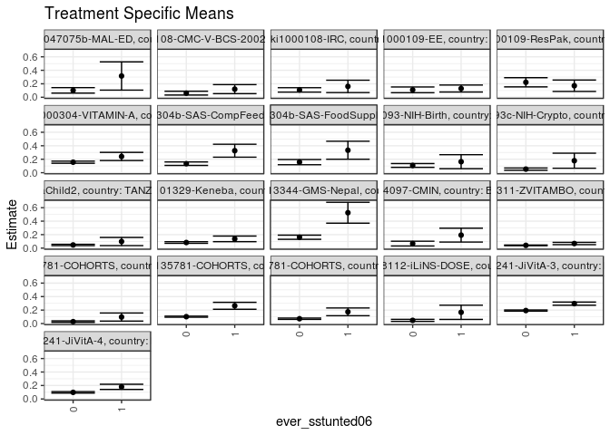

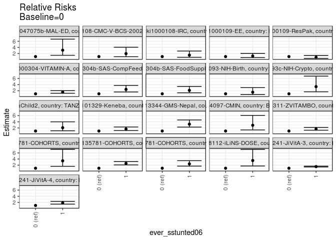

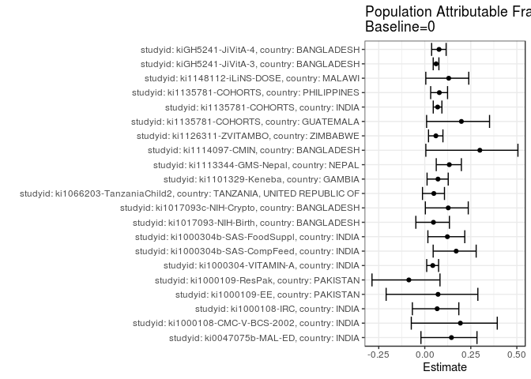

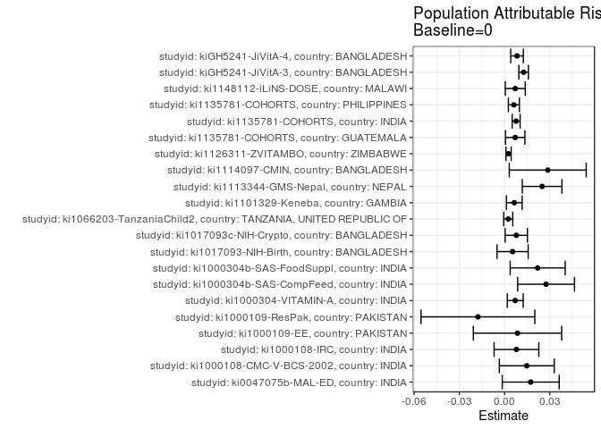

## Results Table

### Parameter: TSM

| studyid | country | intervention_level | baseline_level | estimate | ci_lower | ci_upper |
| --- | --- | --- | --- | --- | --- | --- |
| ki0047075b-MAL-ED | INDIA | 0 | NA | 0.1023256 | 0.0617270 | 0.1429241 |
| ki0047075b-MAL-ED | INDIA | 1 | NA | 0.3157895 | 0.1063324 | 0.5252465 |
| ki1000108-CMC-V-BCS-2002 | INDIA | 0 | NA | 0.0613718 | 0.0330690 | 0.0896747 |
| ki1000108-CMC-V-BCS-2002 | INDIA | 1 | NA | 0.1208791 | 0.0538107 | 0.1879476 |
| ki1000108-IRC | INDIA | 0 | NA | 0.1091954 | 0.0763872 | 0.1420036 |
| ki1000108-IRC | INDIA | 1 | NA | 0.1612903 | 0.0696277 | 0.2529530 |
| ki1000109-EE | PAKISTAN | 0 | NA | 0.1100478 | 0.0675629 | 0.1525328 |
| ki1000109-EE | PAKISTAN | 1 | NA | 0.1296296 | 0.0778355 | 0.1814238 |
| ki1000109-ResPak | PAKISTAN | 0 | NA | 0.2222222 | 0.1541645 | 0.2902800 |
| ki1000109-ResPak | PAKISTAN | 1 | NA | 0.1710526 | 0.0862012 | 0.2559040 |
| ki1000304-VITAMIN-A | INDIA | 0 | NA | 0.1557028 | 0.1402400 | 0.1711656 |
| ki1000304-VITAMIN-A | INDIA | 1 | NA | 0.2408377 | 0.1801843 | 0.3014911 |
| ki1000304b-SAS-CompFeed | INDIA | 0 | NA | 0.1337360 | 0.1080820 | 0.1593900 |
| ki1000304b-SAS-CompFeed | INDIA | 1 | NA | 0.3264249 | 0.2305024 | 0.4223474 |
| ki1000304b-SAS-FoodSuppl | INDIA | 0 | NA | 0.1568047 | 0.1179900 | 0.1956195 |
| ki1000304b-SAS-FoodSuppl | INDIA | 1 | NA | 0.3333333 | 0.1998016 | 0.4668651 |
| ki1017093-NIH-Birth | BANGLADESH | 0 | NA | 0.1075269 | 0.0793430 | 0.1357107 |
| ki1017093-NIH-Birth | BANGLADESH | 1 | NA | 0.1632653 | 0.0596763 | 0.2668543 |
| ki1017093c-NIH-Crypto | BANGLADESH | 0 | NA | 0.0531758 | 0.0362618 | 0.0700898 |
| ki1017093c-NIH-Crypto | BANGLADESH | 1 | NA | 0.1777778 | 0.0659947 | 0.2895609 |
| ki1066203-TanzaniaChild2 | TANZANIA, UNITED REPUBLIC OF | 0 | NA | 0.0470202 | 0.0373165 | 0.0567240 |
| ki1066203-TanzaniaChild2 | TANZANIA, UNITED REPUBLIC OF | 1 | NA | 0.0978261 | 0.0371050 | 0.1585472 |
| ki1101329-Keneba | GAMBIA | 0 | NA | 0.0832049 | 0.0709341 | 0.0954758 |
| ki1101329-Keneba | GAMBIA | 1 | NA | 0.1374046 | 0.0957080 | 0.1791011 |
| ki1113344-GMS-Nepal | NEPAL | 0 | NA | 0.1617647 | 0.1307944 | 0.1927350 |
| ki1113344-GMS-Nepal | NEPAL | 1 | NA | 0.5250000 | 0.3701124 | 0.6798876 |
| ki1114097-CMIN | BANGLADESH | 0 | NA | 0.0670103 | 0.0317551 | 0.1022655 |
| ki1114097-CMIN | BANGLADESH | 1 | NA | 0.1929825 | 0.0903280 | 0.2956369 |
| ki1126311-ZVITAMBO | ZIMBABWE | 0 | NA | 0.0411757 | 0.0367440 | 0.0456074 |
| ki1126311-ZVITAMBO | ZIMBABWE | 1 | NA | 0.0682635 | 0.0511566 | 0.0853704 |
| ki1135781-COHORTS | GUATEMALA | 0 | NA | 0.0283251 | 0.0169080 | 0.0397422 |
| ki1135781-COHORTS | GUATEMALA | 1 | NA | 0.0967742 | 0.0366534 | 0.1568950 |
| ki1135781-COHORTS | INDIA | 0 | NA | 0.1020227 | 0.0941199 | 0.1099255 |
| ki1135781-COHORTS | INDIA | 1 | NA | 0.2633452 | 0.2118429 | 0.3148475 |
| ki1135781-COHORTS | PHILIPPINES | 0 | NA | 0.0718147 | 0.0618698 | 0.0817596 |
| ki1135781-COHORTS | PHILIPPINES | 1 | NA | 0.1736527 | 0.1161894 | 0.2311160 |
| ki1148112-iLiNS-DOSE | MALAWI | 0 | NA | 0.0474308 | 0.0322996 | 0.0625621 |
| ki1148112-iLiNS-DOSE | MALAWI | 1 | NA | 0.1666667 | 0.0611720 | 0.2721613 |
| kiGH5241-JiVitA-3 | BANGLADESH | 0 | NA | 0.1930007 | 0.1849546 | 0.2010468 |
| kiGH5241-JiVitA-3 | BANGLADESH | 1 | NA | 0.2956621 | 0.2720494 | 0.3192748 |
| kiGH5241-JiVitA-4 | BANGLADESH | 0 | NA | 0.0982850 | 0.0870406 | 0.1095293 |
| kiGH5241-JiVitA-4 | BANGLADESH | 1 | NA | 0.1800391 | 0.1414209 | 0.2186574 |

### Parameter: E(Y)

| studyid | country | intervention_level | baseline_level | estimate | ci_lower | ci_upper |
| --- | --- | --- | --- | --- | --- | --- |
| ki0047075b-MAL-ED | INDIA | NA | NA | 0.1196581 | 0.0779840 | 0.1613323 |
| ki1000108-CMC-V-BCS-2002 | INDIA | NA | NA | 0.0760870 | 0.0489610 | 0.1032130 |
| ki1000108-IRC | INDIA | NA | NA | 0.1170732 | 0.0859146 | 0.1482317 |
| ki1000109-EE | PAKISTAN | NA | NA | 0.1185984 | 0.0856546 | 0.1515422 |
| ki1000109-ResPak | PAKISTAN | NA | NA | 0.2045455 | 0.1511224 | 0.2579685 |
| ki1000304-VITAMIN-A | INDIA | NA | NA | 0.1627604 | 0.1476839 | 0.1778369 |
| ki1000304b-SAS-CompFeed | INDIA | NA | NA | 0.1612426 | 0.1416314 | 0.1808538 |
| ki1000304b-SAS-FoodSuppl | INDIA | NA | NA | 0.1787565 | 0.1404842 | 0.2170288 |
| ki1017093-NIH-Birth | BANGLADESH | NA | NA | 0.1128405 | 0.0854611 | 0.1402198 |
| ki1017093c-NIH-Crypto | BANGLADESH | NA | NA | 0.0609418 | 0.0434802 | 0.0784034 |
| ki1066203-TanzaniaChild2 | TANZANIA, UNITED REPUBLIC OF | NA | NA | 0.0494534 | 0.0397554 | 0.0591514 |
| ki1101329-Keneba | GAMBIA | NA | NA | 0.0896333 | 0.0777184 | 0.1015482 |
| ki1113344-GMS-Nepal | NEPAL | NA | NA | 0.1866438 | 0.1550166 | 0.2182711 |
| ki1114097-CMIN | BANGLADESH | NA | NA | 0.0956175 | 0.0591654 | 0.1320697 |
| ki1126311-ZVITAMBO | ZIMBABWE | NA | NA | 0.0438186 | 0.0394817 | 0.0481556 |
| ki1135781-COHORTS | GUATEMALA | NA | NA | 0.0353591 | 0.0233199 | 0.0473983 |
| ki1135781-COHORTS | INDIA | NA | NA | 0.1096840 | 0.1017209 | 0.1176470 |
| ki1135781-COHORTS | PHILIPPINES | NA | NA | 0.0779833 | 0.0679723 | 0.0879943 |
| ki1148112-iLiNS-DOSE | MALAWI | NA | NA | 0.0545229 | 0.0388484 | 0.0701975 |
| kiGH5241-JiVitA-3 | BANGLADESH | NA | NA | 0.2056324 | 0.1980748 | 0.2131900 |
| kiGH5241-JiVitA-4 | BANGLADESH | NA | NA | 0.1065428 | 0.0957758 | 0.1173098 |

### Parameter: RR

| studyid | country | intervention_level | baseline_level | estimate | ci_lower | ci_upper |
| --- | --- | --- | --- | --- | --- | --- |
| ki0047075b-MAL-ED | INDIA | 0 | 0 | 1.0000000 | 1.0000000 | 1.000000 |
| ki0047075b-MAL-ED | INDIA | 1 | 0 | 3.0861244 | 1.4247928 | 6.684596 |
| ki1000108-CMC-V-BCS-2002 | INDIA | 0 | 0 | 1.0000000 | 1.0000000 | 1.000000 |
| ki1000108-CMC-V-BCS-2002 | INDIA | 1 | 0 | 1.9696186 | 0.9573045 | 4.052417 |
| ki1000108-IRC | INDIA | 0 | 0 | 1.0000000 | 1.0000000 | 1.000000 |
| ki1000108-IRC | INDIA | 1 | 0 | 1.4770798 | 0.7766418 | 2.809229 |
| ki1000109-EE | PAKISTAN | 0 | 0 | 1.0000000 | 1.0000000 | 1.000000 |
| ki1000109-EE | PAKISTAN | 1 | 0 | 1.1779388 | 0.6758198 | 2.053121 |
| ki1000109-ResPak | PAKISTAN | 0 | 0 | 1.0000000 | 1.0000000 | 1.000000 |
| ki1000109-ResPak | PAKISTAN | 1 | 0 | 0.7697368 | 0.4296923 | 1.378882 |
| ki1000304-VITAMIN-A | INDIA | 0 | 0 | 1.0000000 | 1.0000000 | 1.000000 |
| ki1000304-VITAMIN-A | INDIA | 1 | 0 | 1.5467783 | 1.1799327 | 2.027677 |
| ki1000304b-SAS-CompFeed | INDIA | 0 | 0 | 1.0000000 | 1.0000000 | 1.000000 |
| ki1000304b-SAS-CompFeed | INDIA | 1 | 0 | 2.4408156 | 1.5988846 | 3.726086 |
| ki1000304b-SAS-FoodSuppl | INDIA | 0 | 0 | 1.0000000 | 1.0000000 | 1.000000 |
| ki1000304b-SAS-FoodSuppl | INDIA | 1 | 0 | 2.1257862 | 1.3274210 | 3.404321 |
| ki1017093-NIH-Birth | BANGLADESH | 0 | 0 | 1.0000000 | 1.0000000 | 1.000000 |
| ki1017093-NIH-Birth | BANGLADESH | 1 | 0 | 1.5183673 | 0.7642537 | 3.016589 |
| ki1017093c-NIH-Crypto | BANGLADESH | 0 | 0 | 1.0000000 | 1.0000000 | 1.000000 |
| ki1017093c-NIH-Crypto | BANGLADESH | 1 | 0 | 3.3432099 | 1.6524803 | 6.763804 |
| ki1066203-TanzaniaChild2 | TANZANIA, UNITED REPUBLIC OF | 0 | 0 | 1.0000000 | 1.0000000 | 1.000000 |
| ki1066203-TanzaniaChild2 | TANZANIA, UNITED REPUBLIC OF | 1 | 0 | 2.0805106 | 1.0816633 | 4.001730 |
| ki1101329-Keneba | GAMBIA | 0 | 0 | 1.0000000 | 1.0000000 | 1.000000 |
| ki1101329-Keneba | GAMBIA | 1 | 0 | 1.6513995 | 1.1784814 | 2.314097 |
| ki1113344-GMS-Nepal | NEPAL | 0 | 0 | 1.0000000 | 1.0000000 | 1.000000 |
| ki1113344-GMS-Nepal | NEPAL | 1 | 0 | 3.2454545 | 2.2831469 | 4.613359 |
| ki1114097-CMIN | BANGLADESH | 0 | 0 | 1.0000000 | 1.0000000 | 1.000000 |
| ki1114097-CMIN | BANGLADESH | 1 | 0 | 2.8798920 | 1.3628594 | 6.085572 |
| ki1126311-ZVITAMBO | ZIMBABWE | 0 | 0 | 1.0000000 | 1.0000000 | 1.000000 |
| ki1126311-ZVITAMBO | ZIMBABWE | 1 | 0 | 1.6578579 | 1.2621171 | 2.177684 |
| ki1135781-COHORTS | GUATEMALA | 0 | 0 | 1.0000000 | 1.0000000 | 1.000000 |
| ki1135781-COHORTS | GUATEMALA | 1 | 0 | 3.4165498 | 1.6291833 | 7.164825 |
| ki1135781-COHORTS | INDIA | 0 | 0 | 1.0000000 | 1.0000000 | 1.000000 |
| ki1135781-COHORTS | INDIA | 1 | 0 | 2.5812409 | 2.0915786 | 3.185539 |
| ki1135781-COHORTS | PHILIPPINES | 0 | 0 | 1.0000000 | 1.0000000 | 1.000000 |
| ki1135781-COHORTS | PHILIPPINES | 1 | 0 | 2.4180671 | 1.6891941 | 3.461443 |
| ki1148112-iLiNS-DOSE | MALAWI | 0 | 0 | 1.0000000 | 1.0000000 | 1.000000 |
| ki1148112-iLiNS-DOSE | MALAWI | 1 | 0 | 3.5138888 | 1.7296293 | 7.138764 |
| kiGH5241-JiVitA-3 | BANGLADESH | 0 | 0 | 1.0000000 | 1.0000000 | 1.000000 |
| kiGH5241-JiVitA-3 | BANGLADESH | 1 | 0 | 1.5319223 | 1.3980645 | 1.678596 |
| kiGH5241-JiVitA-4 | BANGLADESH | 0 | 0 | 1.0000000 | 1.0000000 | 1.000000 |
| kiGH5241-JiVitA-4 | BANGLADESH | 1 | 0 | 1.8318076 | 1.4314955 | 2.344065 |

### Parameter: PAR

| studyid | country | intervention_level | baseline_level | estimate | ci_lower | ci_upper |
| --- | --- | --- | --- | --- | --- | --- |
| ki0047075b-MAL-ED | INDIA | 0 | NA | 0.0173325 | -0.0015396 | 0.0362047 |
| ki1000108-CMC-V-BCS-2002 | INDIA | 0 | NA | 0.0147151 | -0.0034766 | 0.0329069 |
| ki1000108-IRC | INDIA | 0 | NA | 0.0078778 | -0.0069552 | 0.0227108 |
| ki1000109-EE | PAKISTAN | 0 | NA | 0.0085505 | -0.0207177 | 0.0378188 |
| ki1000109-ResPak | PAKISTAN | 0 | NA | -0.0176768 | -0.0553909 | 0.0200374 |
| ki1000304-VITAMIN-A | INDIA | 0 | NA | 0.0070576 | 0.0017808 | 0.0123344 |
| ki1000304b-SAS-CompFeed | INDIA | 0 | NA | 0.0275066 | 0.0086667 | 0.0463465 |
| ki1000304b-SAS-FoodSuppl | INDIA | 0 | NA | 0.0219517 | 0.0037068 | 0.0401967 |
| ki1017093-NIH-Birth | BANGLADESH | 0 | NA | 0.0053136 | -0.0050182 | 0.0156453 |
| ki1017093c-NIH-Crypto | BANGLADESH | 0 | NA | 0.0077661 | 0.0003846 | 0.0151475 |
| ki1066203-TanzaniaChild2 | TANZANIA, UNITED REPUBLIC OF | 0 | NA | 0.0024332 | -0.0005515 | 0.0054178 |
| ki1101329-Keneba | GAMBIA | 0 | NA | 0.0064284 | 0.0012217 | 0.0116351 |
| ki1113344-GMS-Nepal | NEPAL | 0 | NA | 0.0248791 | 0.0117447 | 0.0380135 |
| ki1114097-CMIN | BANGLADESH | 0 | NA | 0.0286072 | 0.0031053 | 0.0541091 |
| ki1126311-ZVITAMBO | ZIMBABWE | 0 | NA | 0.0026429 | 0.0009103 | 0.0043755 |
| ki1135781-COHORTS | GUATEMALA | 0 | NA | 0.0070340 | 0.0006011 | 0.0134669 |
| ki1135781-COHORTS | INDIA | 0 | NA | 0.0076613 | 0.0050368 | 0.0102857 |
| ki1135781-COHORTS | PHILIPPINES | 0 | NA | 0.0061686 | 0.0025216 | 0.0098157 |
| ki1148112-iLiNS-DOSE | MALAWI | 0 | NA | 0.0070921 | 0.0004608 | 0.0137233 |
| kiGH5241-JiVitA-3 | BANGLADESH | 0 | NA | 0.0126317 | 0.0094602 | 0.0158032 |
| kiGH5241-JiVitA-4 | BANGLADESH | 0 | NA | 0.0082578 | 0.0040801 | 0.0124356 |

### Parameter: PAF

| studyid | country | intervention_level | baseline_level | estimate | ci_lower | ci_upper |
| --- | --- | --- | --- | --- | --- | --- |
| ki0047075b-MAL-ED | INDIA | 0 | NA | 0.1448505 | -0.0207766 | 0.2836036 |
| ki1000108-CMC-V-BCS-2002 | INDIA | 0 | NA | 0.1933987 | -0.0731571 | 0.3937461 |
| ki1000108-IRC | INDIA | 0 | NA | 0.0672893 | -0.0673230 | 0.1849241 |
| ki1000109-EE | PAKISTAN | 0 | NA | 0.0720966 | -0.2098228 | 0.2883216 |
| ki1000109-ResPak | PAKISTAN | 0 | NA | -0.0864198 | -0.2866465 | 0.0826479 |
| ki1000304-VITAMIN-A | INDIA | 0 | NA | 0.0433620 | 0.0105479 | 0.0750879 |
| ki1000304b-SAS-CompFeed | INDIA | 0 | NA | 0.1705915 | 0.0456308 | 0.2791905 |
| ki1000304b-SAS-FoodSuppl | INDIA | 0 | NA | 0.1228025 | 0.0169346 | 0.2172693 |
| ki1017093-NIH-Birth | BANGLADESH | 0 | NA | 0.0470894 | -0.0484184 | 0.1338966 |
| ki1017093c-NIH-Crypto | BANGLADESH | 0 | NA | 0.1274339 | 0.0032097 | 0.2361767 |
| ki1066203-TanzaniaChild2 | TANZANIA, UNITED REPUBLIC OF | 0 | NA | 0.0492015 | -0.0123635 | 0.1070224 |
| ki1101329-Keneba | GAMBIA | 0 | NA | 0.0717187 | 0.0124578 | 0.1274235 |
| ki1113344-GMS-Nepal | NEPAL | 0 | NA | 0.1332974 | 0.0623927 | 0.1988400 |
| ki1114097-CMIN | BANGLADESH | 0 | NA | 0.2991838 | 0.0058233 | 0.5059799 |
| ki1126311-ZVITAMBO | ZIMBABWE | 0 | NA | 0.0603154 | 0.0203632 | 0.0986383 |
| ki1135781-COHORTS | GUATEMALA | 0 | NA | 0.1989301 | 0.0099812 | 0.3518174 |
| ki1135781-COHORTS | INDIA | 0 | NA | 0.0698484 | 0.0460397 | 0.0930629 |
| ki1135781-COHORTS | PHILIPPINES | 0 | NA | 0.0791021 | 0.0321159 | 0.1238074 |
| ki1148112-iLiNS-DOSE | MALAWI | 0 | NA | 0.1300755 | 0.0056017 | 0.2389682 |
| kiGH5241-JiVitA-3 | BANGLADESH | 0 | NA | 0.0614285 | 0.0458265 | 0.0767754 |
| kiGH5241-JiVitA-4 | BANGLADESH | 0 | NA | 0.0775072 | 0.0372653 | 0.1160670 |